# Assignment 11: Detecting Overfitting and Overfitting Issues

Sam Johnson

Due: April 2026

## **Assignment Objectives**

- Enhance understanding the procedure of likelihood-based chi-square hypothesis testing .
- Implement the procedures for detecting overfitting/underfitting issues in practical applications.

## **Policies of Using AI Tools**

**Policy on AI Tool Use**: Please adhere to the AI tool policy specified in the course syllabus. The direct copying of AI-generated content is strictly prohibited. All submitted work must reflect your own understanding; where external tools are consulted, content must be thoroughly rephrased and synthesized in your own words.

**Code Inclusion Requirement**: Any code included in your essay must be properly commented to explain the purpose and/or expected output of key code lines. Submitting AI-generated code without meaningful, student-added comments will not be accepted.

## Testing Overfitting/Underfitting

In Machine Learning and Statistics, overfitting occurs when a model is too complex and learns noise, leading to poor performance on new data, while underfitting happens when a model is too simple to capture important patterns, resulting in high errors overall; both issues are explained by the Bias–Variance Tradeoff and can cause unreliable predictions in real-world applications.

The probability density function (PDF) of the Weibull distribution is:

$$f(t; \lambda, \beta) = \frac{\beta}{\lambda} \left( \frac{t}{\lambda}
\right)^{\beta-1} \exp\left[ -\left( \frac{t}{\lambda} \right)^\beta
\right], \quad t \ge 0$$
where $\lambda > 0$ is the scale parameter (characteristic life) and $\beta > 0$ is the shape parameter.

When $\beta = 1$, the Weibull PDF simplifies to the exponential PDF:

$$f(t; \lambda) = \frac{1}{\lambda} \exp\left( -\frac{t}{\lambda} \right)$$
with constant hazard rate $h(t) = 1/\lambda$.

**This assignment focuses on performing a hypothesis test for the shape parameter ($\beta$) of the Weibull distribution within a reliability mode**

$$\begin{align}
H_0&: \beta = 1 \quad \text{(Exponential model, simpler)} \\
H_1&: \beta \neq 1 \quad \text{(Weibull model, more complex)}
\end{align}$$

## **Question: Reliability Application**

A mid-sized manufacturing company producing industrial conveyor systems began experiencing unexpected downtime in one of its distribution facilities, prompting concern about the reliability of a newly sourced batch of ball bearings used in the motor assemblies. These bearings, supplied by a vendor adopting cost-saving production methods, were installed across multiple units operating under continuous load conditions. After several months, maintenance logs revealed a pattern of increasing failures, with components lasting anywhere from a few dozen to over 150 hours before breakdown. To investigate, the engineering team collected time-to-failure data from 50 identical bearings and conducted a Weibull analysis within the framework of Reliability Engineering. The 50 time-to-failure (survival time) are:

```
12.4, 18.7, 25.3, 30.1, 33.5, 35.2, 38.9, 40.3, 42.7, 45.1, 47.6, 49.8, 52.4, 55.0,
57.3, 60.2, 62.8, 65.1, 67.9, 70.5, 72.3, 75.6, 78.2, 80.9, 83.4, 85.7, 88.1, 90.6,
93.2, 95.8, 98.4, 101.0, 104.5, 107.3, 110.6, 113.2, 116.8, 120.1, 123.7, 127.4,
130.9, 134.5, 138.2, 142.0, 146.3, 150.7, 155.2, 160.8, 168.4, 175.9
```

This assignment focuses on hypothesis $H_0: \beta = 1$ (exponential) against $H_1: \beta \neq 1$ (Weibull). This framework detects overfitting (fitting a Weibull when exponential is true) and underfitting (fitting exponential when Weibull with $\beta \neq 1$ is true).

a). Find the MLE of the Weibull parameters $\lambda$ (scale) and $\beta$ (shape), denoted by $\hat{\lambda}$ and $\hat{\beta}$, respectively, using the `optim()` procedure. [*Hint: You should provide explicit expressions for the log-likelihood and gradient functions of the Weibull distribution parameters.*]

We find the log likelihood of the Weibull distribution per the above parameterization

$$\begin{eqnarray*}
\ell \left(\beta, \lambda; t \right) &=& \log \prod_i f
\left(t_i; \beta, \lambda \right)\\
&=& \sum_i \log f \left(t_i; \beta, \lambda \right)\\
&=& \sum_i \log\left[\frac{\beta}{\lambda} \left(
\frac{t_i}{\lambda} \right)^{\beta-1} \exp\left( -\left(
\frac{t_i}{\lambda} \right)^{\beta}\right) \right]\\
&=& \sum_i \log\left[\frac{\beta
t_i^{\beta-1}}{\lambda^{\beta}} \exp\left( -\left( \frac{t_i}{\lambda}
\right)^{\beta}\right) \right]\\
&=& \sum_i \log \frac{\beta
t_i^{\beta-1}}{\lambda^{\beta}} -\sum_i\left( \frac{t_i}{\lambda}
\right)^{\beta}\\
&=& \sum_i \log \beta + \sum \log t_i^{\beta-1} - \sum_i
\log \lambda ^ {\beta} - \lambda^{-\beta} \sum_i t_i^{\beta}\\
&=& n \log \beta - n \beta \log \lambda + \left(\beta -
1\right)\sum_i \log t_i - \lambda^{-\beta} \sum_i t_i^{\beta}
\end{eqnarray*}$$

Now we compute the partial derivatives with respect to each of the parameters to find the score function

$$\begin{eqnarray*}
\frac{\partial}{\partial \beta} \ell \left(\beta, \lambda;
t\right) &=& \frac{\partial}{\partial \beta} \left[n \log \beta
- n \beta \log \lambda + \left(\beta - 1\right)\sum_i \log t_i -
\lambda^{-\beta} \sum_i t_i^{\beta} \right]\\
&=& \frac{n}{\beta} - n \log \lambda + \sum_i \log t_i -
\frac{\partial}{\partial \beta} \lambda^{-\beta} \sum_i t_i^{\beta}\\
&=& \frac{n}{\beta} - n \log \lambda + \sum_i \log t_i -
\left[ \lambda^{-\beta} \frac{\partial}{\partial \beta}\sum_i
t_i^{\beta} + \left(\sum_i t_i^{\beta}\right) \frac{\partial}{\partial
\beta}\lambda^{-\beta} \right]\\
&=& \frac{n}{\beta} - n \log \lambda + \sum_i \log t_i -
\left[ \lambda^{-\beta} \sum_i t_i^{\beta} \log{t_i} -
\lambda^{-\beta}\log \lambda\sum_i t_i^{\beta} \right]\\
&=& \frac{n}{\beta} - n \log \lambda + \sum_i \log t_i
+ \lambda^{-\beta}\log \lambda\sum_i t_i^{\beta} - \lambda^{-\beta}
\sum_i t_i^{\beta} \log t_i
\end{eqnarray*}$$

$$\begin{eqnarray*}
\frac{\partial}{\partial \lambda} \ell \left(\beta, \lambda;
t\right) &=& \frac{\partial}{\partial \lambda} \left[n \log
\beta - n \beta \log \lambda + \left(\beta - 1\right)\sum_i \log t_i -
\lambda^{-\beta} \sum_i t_i^{\beta} \right]\\
&=& -\frac{n \beta}{\lambda} - \frac{\partial}{\partial
\lambda} \lambda^{- \beta} \sum_i t_i^{\beta}\\
&=& - \frac{n \beta}{\lambda} + \beta \lambda^{-\beta-1}
\sum_i t_i^{\beta}
\end{eqnarray*}$$

$$\nabla \ell \left(\beta, \lambda; t\right) = \left \langle
\frac{n}{\beta} - n \log \lambda + \sum_i \log t_i
+ \lambda^{-\beta}\log \lambda\sum_i t_i^{\beta} - \lambda^{-\beta}
\sum_i t_i^{\beta} \log t_i, - \frac{n \beta}{\lambda} + \beta
\lambda^{-\beta-1} \sum_i t_i^{\beta} \right \rangle$$

Now we use r to find the MLE for this particular set of survival times.

```r
X <- c(12.4, 18.7, 25.3, 30.1, 33.5, 35.2, 38.9, 40.3, 42.7, 45.1, 47.6, 49.8, 52.4, 55.0,
       57.3, 60.2, 62.8, 65.1, 67.9, 70.5, 72.3, 75.6, 78.2, 80.9, 83.4, 85.7, 88.1, 90.6,
       93.2, 95.8, 98.4, 101.0, 104.5, 107.3, 110.6, 113.2, 116.8, 120.1, 123.7, 127.4,
       130.9, 134.5, 138.2, 142.0, 146.3, 150.7, 155.2, 160.8, 168.4, 175.9)

weibull_log_likelihood <- function(beta, lambda, X){
  n <- length(X)
  n * log(beta) - n * beta * log(lambda) + (beta - 1) * sum(log(X)) - lambda^(-beta) * sum(X^beta)
}

weibull_score <- function(beta, lambda, X){
  n <- length(X)
  score_beta <- n / beta - n * log(lambda) +  sum(log(X)) + lambda ^ (-beta) * log(lambda) * sum(X^beta) -  lambda^(-beta) * sum(X^beta * log(X))
  score_lambda <- -n * beta / lambda + beta * lambda^(-beta-1) * sum(X^beta)
  c(score_beta, score_lambda)
}

score_closure <- function(params){
  weibull_score(params[1], params[2], X)
}

likelihood_closure <- function(params){
  weibull_log_likelihood(params[1], params[2], X)
}

weibull_result <- optim(
  par = c(2, 2),
  #need to provide initial values to start the iteration.
  # Choosing appropriate initial values is critical.
  fn = likelihood_closure,      # Caution: need negative log-likelihood
  gr = score_closure,           # also nee negative score
  method = "BFGS",          # calling BFGS algorithm
  hessian = TRUE,           # return Hessian matrix
  control = list(           # some controls in numerical iteration
    fnscale = -1,       # turn the minimization to maximization problem
    maxit = 1000,       # stopping rule 1: cap number of iterations
    reltol = 1e-8,      # stopping rule: precision control
    REPORT = 10         # The algorithm will print progress updates
    # every 10 iterations
  )
)
#assert convergence
stopifnot(weibull_result$convergence == 0)

#assert all variances are positive
covariance <- solve(-weibull_result$hessian)
stopifnot(all(diag(covariance) > 0))
weibull_result
```

```
$par
[1]  2.205726 98.996613

$value
[1] -256.4198

$counts
function gradient
      81       37

$convergence
[1] 0

$message
NULL

$hessian
            [,1]        [,2]
[1,] -17.6016481  0.20605006
[2,]   0.2060501 -0.02483901
```

MLE parameters $\hat{\boldsymbol{\theta}}_{weibull} = \left\langle \hat{\beta}, \hat{\lambda} \right\rangle = \langle 2.205726, 98.996613 \rangle$

b). Find the MLE of the exponential parameter $\lambda$ (scale), denoted by $\hat{\lambda}$, using any procedure. [*Hint: You should provide explicit expressions for the log-likelihood and gradient functions of the exponential distribution parameters.*]

Note, exponential is the a weibull distribution with $\beta=1$, we can find the exponential distribution’s score function by plugging $\beta=1$ into weibull’s score function.

$$\begin{eqnarray*}
- \frac{n \beta}{\lambda} + \beta \lambda^{-\beta-1} \sum_i
t_i^{\beta} \bigg|_{\beta=1} &=& -\frac{n}{\lambda} \lambda^{-2}
\sum_i t_i
\end{eqnarray*}$$

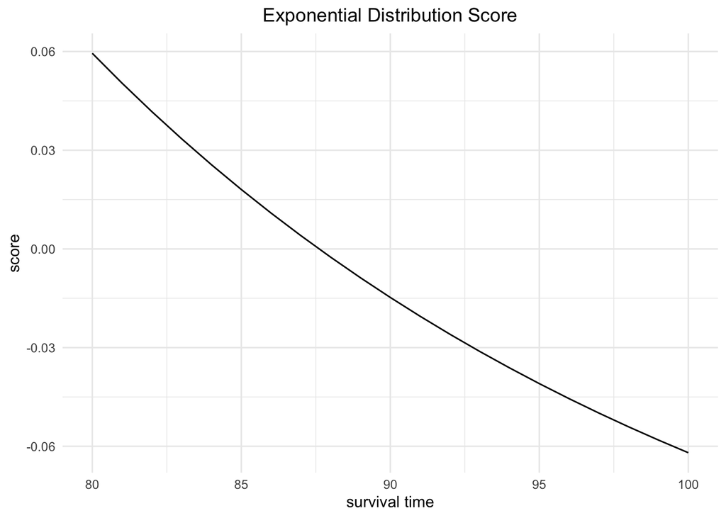

```r
exp_log_likelihood <- function(lambda, X){
  weibull_log_likelihood(1, lambda, X)
}

exp_score <- function(lambda, X){
  weibull <- weibull_score(1, lambda, X)
  weibull[2]
}

score_closure <- function(lambda){
  exp_score(lambda, X)
}

likelihood_closure <- function(lambda){
  exp_log_likelihood(lambda, X)
}

#visually look at plot of score to find the intervals for root finding
plot_data <- data.frame(x=80:100, y=sapply(80:100, score_closure))
ggplot(data=plot_data, aes(x=x, y=y)) +
  geom_line() +
  labs(title="Exponential Distribution Score", x="survival time", y="score") +
  theme_minimal() +
  theme(plot.title = element_text(hjust = 0.5))
```

```r
#search between 85 and 90
exp_lambda <- uniroot(score_closure, c(85, 90))$root
exp_lambda
```

```
[1] 87.61
```

Our MLE parameter for the exponential is $\hat{\lambda}_{\text{exp}} = 87.61$

c). Perform the likelihood ratio $\chi^2$ test on $\beta = 1$. What is the p-value? [*Hint: Use the results in a) and b)*.]

We have the following hypotheses $H_0$: $\beta = 1$ (exponential distribution) $H_a$: $\beta \neq 1$ (weibull)

We test this using the likelihood ratio test

$$\Lambda =
-2[\ell(\tilde{\boldsymbol{\theta}}) -
\ell(\hat{\boldsymbol{\theta}})] = 2[\ell(\hat{\boldsymbol{\theta}}) -
\ell(\tilde{\boldsymbol{\theta}})]$$

where $\Lambda \sim \chi_{1}^2$

```r
likehood_ratio_test_stat <- function(theta_mle, theta_null, log_likehood){
  2 * (log_likehood(theta_mle) - log_likehood(theta_null))
}

#our null hypothesis is that beta is 1 in weibull and lambda the exponential mle
likelihood_test_stat <- likehood_ratio_test_stat(c(2.205726, 98.996613), c(1, 87.61), \(theta) weibull_log_likelihood(theta[1], theta[2], X))
```

p-value: 4.373559e-09

At the $\alpha = 0.05$ significance level, there is sufficient evidence to suggest that $\beta \neq 1$ and thus is not distributed per the exponential distribution.

d). Perform the Wald $\chi^2$ on the same hypothesis $\beta = 1$. What is the p-value? [*Hint: You need to find the observed Fisher information matrix (i.e., the negative Hessian matrix from `optim()`) based on the Weibull distribution. The inverse of the negative observed Hessian matrix is the covariance matrix*.]

Here we test the same hypothesis as above. This time using a Wald $\chi^2$ test.

The Wald $\chi^2$ test statistic $W$ is defined as follows
$$W = \hat{D}^{T} \, \left[
\widehat{\text{var}(\hat{\boldsymbol{\theta}})}\right]^{-1} \,
\hat{D} = \hat{D}^{T} \,\text{I}_n(\hat{\boldsymbol{\theta}}) \,
\hat{D}$$

Where $\hat{D} = \hat{\boldsymbol{\theta}} - \boldsymbol{\theta}_0$

The test statistic is then distributed as follows
$$W \sim \chi_1^2$$

```r
wald_test_statistic <- function(theta_hat, theta_0, fisher_information){
  #here fisher_information is the information of the whole sample,
  #not just a single sample
  D <- theta_hat - theta_0
  #NOTE: %*% is the matmul operator in r
  W <- t(D) %*% fisher_information %*% D
  W[1]
}

#use the fact that observed fisher information is the
#additive inverse of the hessian at the MLE params
wald_test_stat <- wald_test_statistic(weibull_result$par, c(1, exp_lambda), -weibull_result$hessian)
```

p-value: 1.497204e-06

At the $\alpha = 0.05$ significance level, there is sufficient evidence to suggest that $\beta \neq 1$ and thus is not distributed per the exponential distribution.

e). Write a summary of the above analyses to address the following:

- Whether the two tests generated the same results.
- Which model is recommended for the data.
- Draw the density curve based on the MLE(s) of the parameter(s) and describe the distribution of the time-to-failure.

Both the likelihood ratio and the Wald test came to the same conclusion, that $\beta$ was signifigantly different than 1, and thus weibull was more appropriate than exponential. In a situation like this one with a sample same size, it is easy to fit models under both the null and alternative hypotheses. Thus, the likelihood ratio test is availble, and generally provides the best proformance. The wald test is sensitive to parameters near boundaries, and in the above senserio, we are dealing with small values for $\beta$. Therefore, I belivieve the likelihood ratio test is the most appropriate test for this senario.

In terms of choosing the best distribution to model these data, both the hypothesis tests and a visual inspection yeild the same conclusion. Looking at the density plot, I would again choose the weibull distribution. For small times to failure, there appears to be almost no density. This makes sense, as parts are not apt to fail almost instantly. The weibull distribution models this, while the exponential appears to have massive density for small times to failure. Ultimaltly, the weibull distribution appears better than the exponential distribution for modeling this particular set of times to failure.

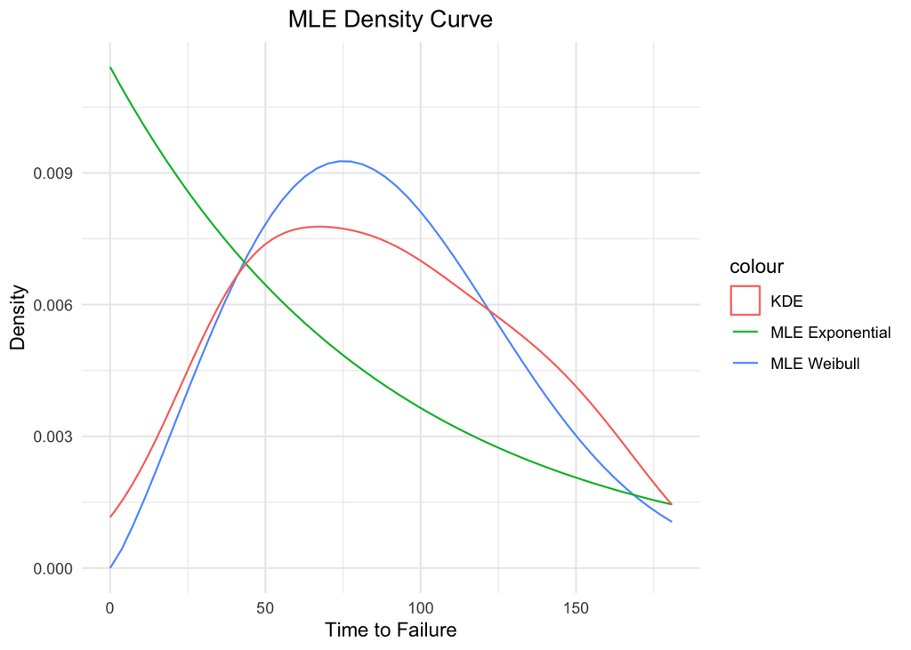

```r
MLE_expoential_density <- function(t){
  #r uses a different parameterization
  rate <- 1 / 87.61
  dexp(t, rate)
}

MLE_weibull_density <- function(t){
  dweibull(t, 2.205726, 98.996613)
}

sample_points <- seq(0, max(X) + 5, length.out=length(X))
plot_data <- data.frame(x=sample_points, y_weibull=MLE_weibull_density(sample_points), y_exp=MLE_expoential_density(sample_points))

ggplot(data=plot_data)+
  geom_line(aes(x=x, y=y_weibull, color="MLE Weibull")) +
  geom_line(aes(x=x, y=y_exp, color="MLE Exponential")) +
  geom_density(aes(x=X, color="KDE")) +
  labs(title="MLE Density Curve", x="Time to Failure", y="Density") +
  theme_minimal() +
  theme(plot.title = element_text(hjust = 0.5))
```